# Modeling and prediction for movies

Raymond Ngiam Heng Aik

09 Aug 2016

## Setup

### Load packages

```r
library(ggplot2)
library(dplyr)
library(statsr)
library(GGally)
library(leaps)
```

### Load data

```r
load("movies.Rdata")
```

## Part 1: Data

**How the observations in the sample are collected:**

The data set is comprised of 651 randomly sampled movies produced and released before 2016 [1].

**Implications of this data collection method on the scope of inference (generalizability):**

Since the data collection involves random sampling, the sample can be considered representative of the population. Hence findings from this observational study can be generalized to the entire population.

**Implications of this data collection method on the scope of inference (causality):**

Since this is an observational study, not an experiment where subjects are randomly assigned for specific treatments, hence, the findings on relationship among different factors only establish association but do not imply causality.

## Part 2: Research question

**Do relationship exist among Rotten Tomatoes’ audience score and the rest of the variables in the “movies.Rdata” dataset?**

This research question is of interest because based on past historical records we can get insights on which variables are having correlation to Rotten Tomatoes’ audience score, which is related to the popularity of movies among audiences. We can then build a linear model to predict the popularity of future movies on average, based on combination of the correlated variables.

## Part 3: Exploratory data analysis

Variables to consider for the full model

1. title_type
2. genre
3. runtime
4. mpaa_rating
5. imdb_rating
6. imdb_num_votes
7. critics_scores
8. critics_rating
9. best_pic_nom
10. best_pic_win
11. best_actor_win
12. best_actress_win
13. best_dir_win
14. top200_box

Excluded variables:

1. title
2. studio
3. thtr_rel_year
4. thtr_rel_month
5. thtr_rel_day
6. dvd_rel_year
7. dvd_rel_month
8. dvd_rel_day
9. director

10-14. actor1-actor5

15. imdb_url
16. rt_url

Reasons for exclusion variables:

Since we are interested to study properties of movies that are influential to the movie’s popularity in general, the variable “title”, “studio”, “director”, and “Actor1”-“Actor5” are excluded because they are too specific. If we use these variables in creating the regression model, the model will only be reasonable in the context of the existing sample of movies. We will not be able to make predictions for movies other that those with “title” among the existing sample. Same goes for “studio”, “director”, and “Actor1”-“Actor5”.

Time related variables such as theatre release date and DVD release date are also excluded because we are interested in long term popularity of movies, not popularity during release in theatre or release of DVD.

Finally, IMDB url and Rotten Tomatoes url are also excluded as they are obviously irrelevant to context of this problem.

```r
movies_no_na <- na.omit(movies)
N = nrow(movies_no_na)
N
```

```
## [1] 619
```

**Univariate analysis**

One of the numeric explanatory variables that is of particular interest is **imdb_num_votes**.

Below is the histogram for the distribution of **imdb_num_votes**,

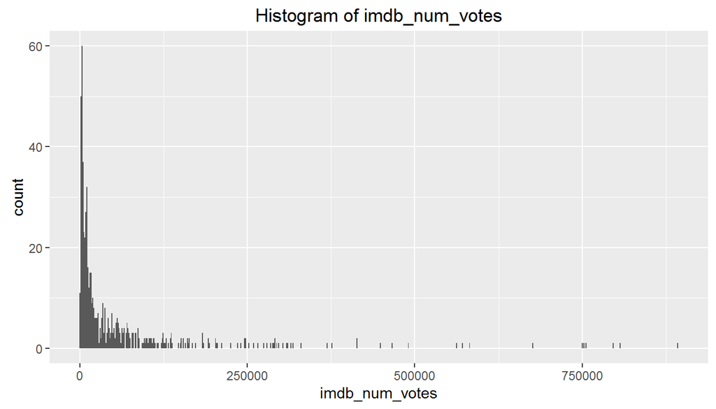

```r
ggplot(data = movies_no_na, aes(x=imdb_num_votes)) +
  geom_histogram(binwidth = 1500) +
  labs(title = "Histogram of imdb_num_votes")
```

```r
range(movies_no_na$imdb_num_votes)
```

```
## [1]    183 893008
```

The range of **imdb_num_votes** is (183, 893008), and it is heavily right-skewed. It will be more meaningful if we apply a log transformation, and name it as a new variable, **limdb_num_votes**.

```r
movies_added_predictors <- movies_no_na %>%
  mutate(limdb_num_votes = log10(imdb_num_votes))
```

Histogram of **limdb_num_votes**

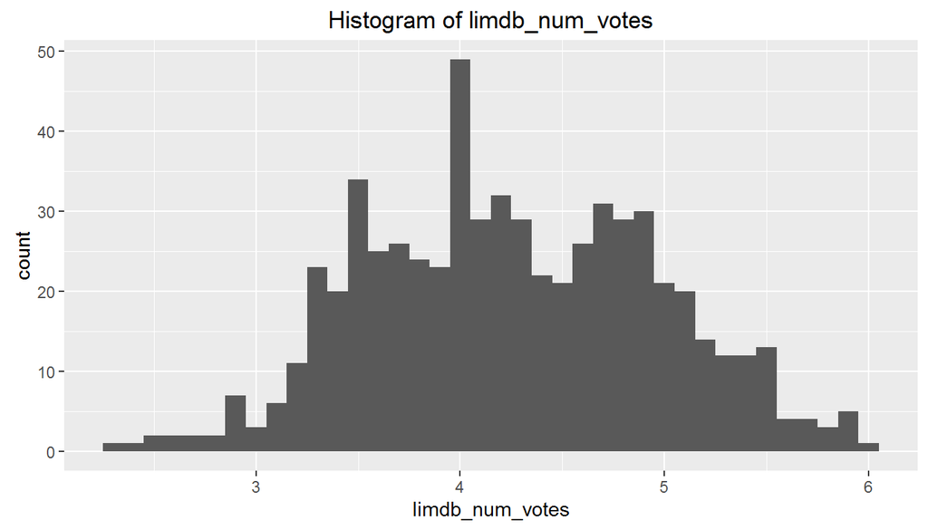

```r
ggplot(data = movies_added_predictors, aes(x=limdb_num_votes)) +
  geom_histogram(binwidth = 0.1) +
  labs(title = "Histogram of limdb_num_votes")
```

**Bivariate analysis between explanatory variable and response variable:**

1. Title type and audience score

Box plot to visualize the differences in audience score distribution among categorical variable, title type.

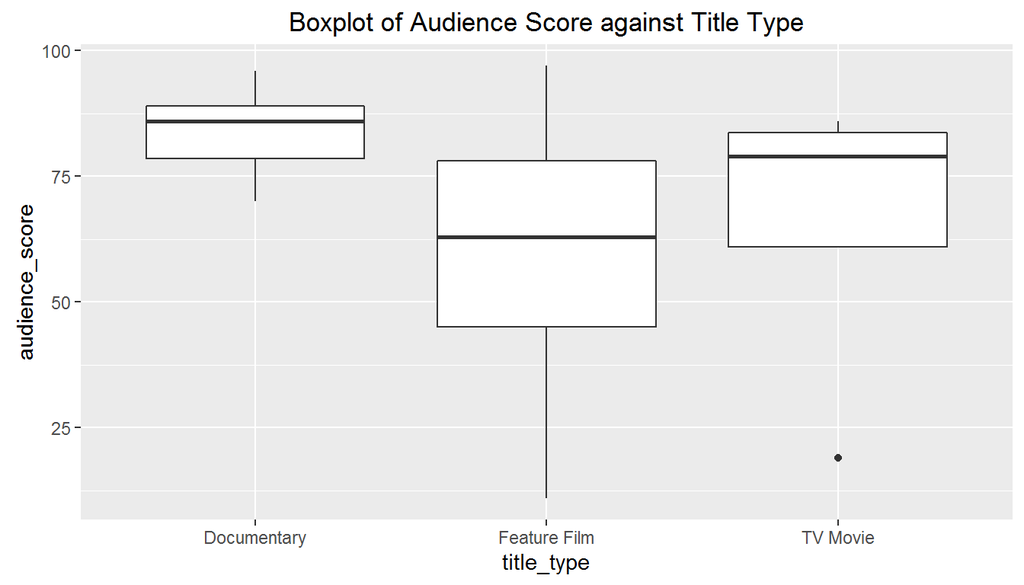

```r
ggplot(data=movies_added_predictors, aes(x=title_type, y=audience_score)) +
  geom_boxplot() +
  labs(title = "Boxplot of Audience Score against Title Type")
```

Summary statistics

```r
movies_added_predictors %>%
  group_by(title_type) %>%
  summarize(mean=mean(audience_score), sd=sd(audience_score),median=median(audience_score),IQR=IQR(audience_score),min=min(audience_score),max=max(audience_score), count=n())
```

```
## # A tibble: 3 x 8
##     title_type     mean        sd median   IQR   min   max count
##         <fctr>    <dbl>     <dbl>  <dbl> <dbl> <dbl> <dbl> <int>
## 1  Documentary 84.14286  7.287046     86 10.50    70    96    42
## 2 Feature Film 60.57766 19.818662     63 33.00    11    97   573
## 3     TV Movie 65.75000 31.510580     79 22.75    19    86     4
```

Interpretation: There are differences in the center of the distribution of audience score among different classes of title type in this data sample. The “Documentary” title type has the highest audience score on average compared to the rest.

2. Genre and audience score

Box plot to visualize the differences in audience score distribution among categorical variable, genre.

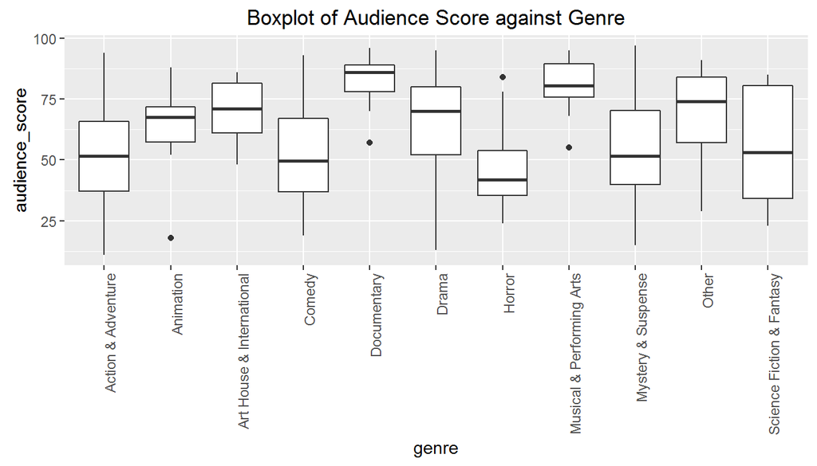

```r
ggplot(data=movies_added_predictors, aes(x=genre, y=audience_score)) +
  geom_boxplot() +
  theme(axis.text.x = element_text(angle = 90, hjust = 1)) +
  labs(title = "Boxplot of Audience Score against Genre")
```

Summary statistics

```r
movies_added_predictors %>%
  group_by(genre) %>%
  summarize(mean=mean(audience_score), sd=sd(audience_score),median=median(audience_score),IQR=IQR(audience_score),min=min(audience_score),max=max(audience_score), count=n())
```

```
## # A tibble: 11 x 8
##                        genre     mean        sd median   IQR   min   max
##                       <fctr>    <dbl>     <dbl>  <dbl> <dbl> <dbl> <dbl>
## 1         Action & Adventure 53.91935 20.006801   51.5 28.50    11    94
## 2                  Animation 62.37500 20.982561   67.5 14.50    18    88
## 3  Art House & International 69.50000 13.641514   71.0 20.50    48    86
## 4                     Comedy 52.24419 19.201676   49.5 30.00    19    93
## 5                Documentary 83.32500  8.504561   86.0 11.00    57    96
## 6                      Drama 65.28859 18.630483   70.0 28.00    13    95
## 7                     Horror 45.90909 16.480606   42.0 18.25    24    84
## 8  Musical & Performing Arts 80.16667 11.360484   80.5 13.75    55    95
## 9         Mystery & Suspense 55.19643 19.277325   51.5 30.25    15    97
## 10                     Other 69.73333 18.491182   74.0 27.00    29    91
## 11 Science Fiction & Fantasy 55.12500 25.759534   53.0 46.25    23    85
## # ... with 1 more variables: count <int>
```

Interpretation: There are differences in the center of the distribution of audience score among different classes of genre in this data sample. The “Documentary” genre has the highest audience score on average compared to the rest.

3. Critics rating and audience score

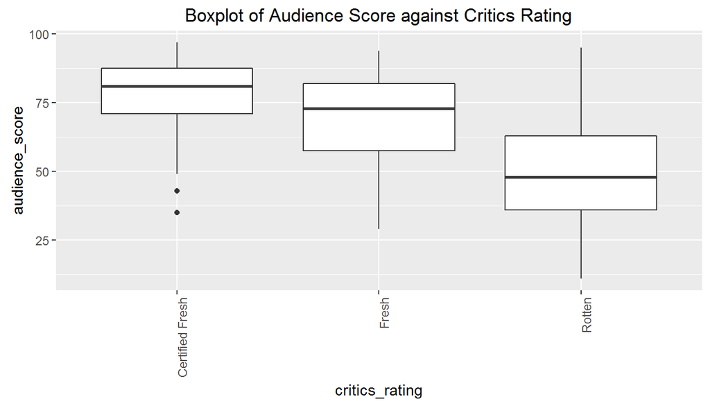

```r
ggplot(data=movies_added_predictors, aes(x=critics_rating, y=audience_score)) +
  geom_boxplot() +
  theme(axis.text.x = element_text(angle = 90, hjust = 1)) +
  labs(title = "Boxplot of Audience Score against Critics Rating")
```

Summary statistics

```r
movies_added_predictors %>%
  group_by(critics_rating) %>%
  summarize(mean=mean(audience_score), sd=sd(audience_score),median=median(audience_score),IQR=IQR(audience_score),min=min(audience_score),max=max(audience_score), count=n())
```

```
## # A tibble: 3 x 8
##    critics_rating     mean       sd median   IQR   min   max count
##            <fctr>    <dbl>    <dbl>  <dbl> <dbl> <dbl> <dbl> <int>
## 1 Certified Fresh 79.41985 11.23658     81  16.5    35    97   131
## 2           Fresh 69.56923 15.69914     73  24.5    29    94   195
## 3          Rotten 49.61775 17.70759     48  27.0    11    95   293
```

Interpretation: There are differences in the center of the distribution of audience score among different classes of critics rating in this data sample. The “Certified Fresh” critics rating has the highest audience score on average compared to the rest.

4. Runtime and audience score

Scatter plot to visualize the correlation between runtime and audience score.

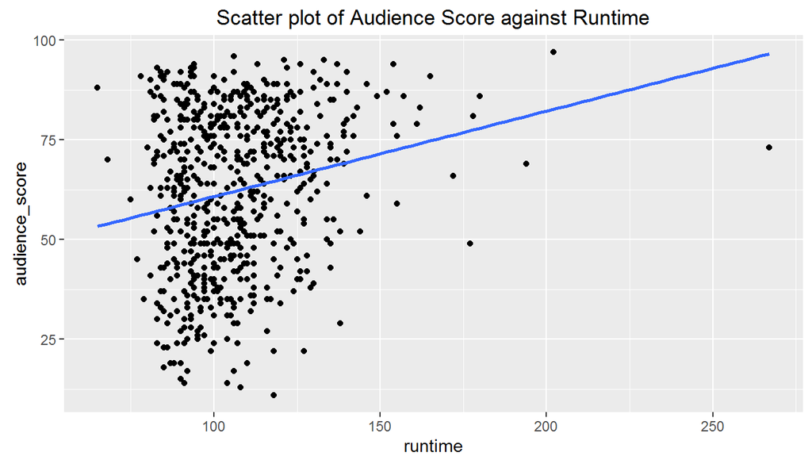

```r
ggplot(data=movies_added_predictors, aes(x=runtime, y=audience_score)) +
  geom_point() +
  geom_smooth(method="lm", se=FALSE) +
  labs(title = "Scatter plot of Audience Score against Runtime")
```

Summary statistic on the correlation.

```r
cor(movies_added_predictors$runtime, movies_added_predictors$audience_score)
```

```
## [1] 0.2031201
```

Interpretation: There is a weak, positive correlation of 0.20 between runtime and audience score.

5. IMDb Rating and audience score

Scatter plot to visualize the correlation between IMDb rating and audience score.

[figure not shown]

```r
ggplot(data=movies_added_predictors, aes(x=imdb_rating, y=audience_score)) +
  geom_jitter() +
  geom_smooth(method="lm", se=FALSE) +
  labs(title = "Scatter plot of Audience Score against IMDb Rating")
```

Summary statistic on the correlation.

```r
cor(movies_added_predictors$imdb_rating, movies_added_predictors$audience_score)
```

```
## [1] 0.8605425
```

Interpretation: There is a strong positive correlation of 0.86 between IMDb rating and audience score.

6. Critics Score and audience score

Scatter plot to visualize the correlation between critics score and audience score.

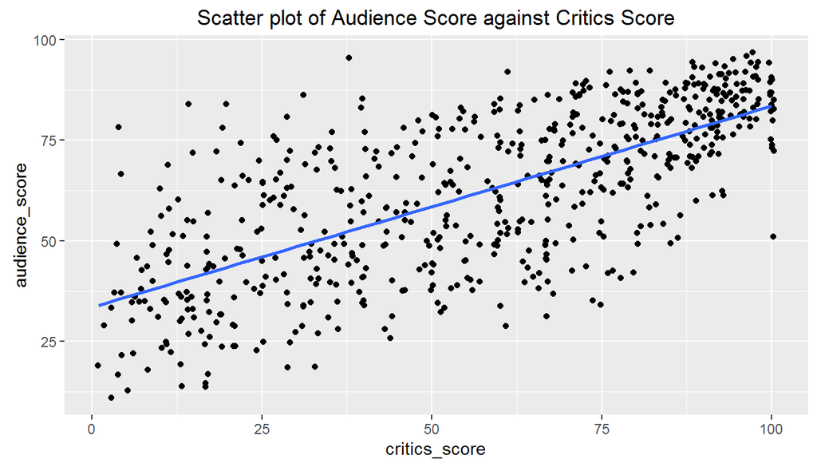

```r
ggplot(data=movies_added_predictors, aes(x=critics_score, y=audience_score)) +
  geom_jitter() +
  geom_smooth(method="lm", se=FALSE) +
  labs(title = "Scatter plot of Audience Score against Critics Score")
```

Summary statistic on the correlation.

```r
cor(movies_added_predictors$critics_score, movies_added_predictors$audience_score)
```

```
## [1] 0.7015256
```

Interpretation: There is a strong positive correlation of 0.70 between critics score and audience score.

**Collinearity analysis among numeric explanatory variables:**

Next, we will explore the correlation among the numeric explanatory variables.

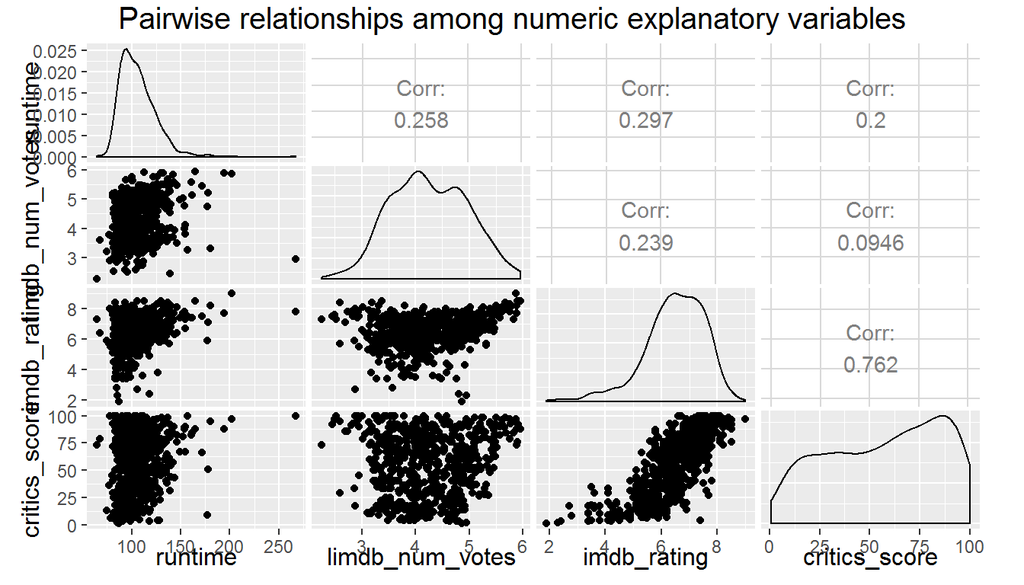

```r
ggpairs(dplyr::select(movies_added_predictors,runtime,limdb_num_votes,imdb_rating,critics_score),title = "Pairwise relationships among numeric explanatory variables")
```

We observed that **imdb_rating** and **critics_score** are highly correlated with correlation coefficient of 0.762, while the rest are not as correlated. Since the two variables are measure of the movie’s popularity, we can compute a weighted average from the two variables to form a new variable **score**.

Since **imdb_rating** is of the range (0,10) and **critics_score** is of the range (0,100), we reweight them by multiply **imdb_rating** with weight 10, and **critics_score** with weight 1, then taking the average of both. The final **score** variable will be of the range (0,100).

```r
movies_added_predictors <- movies_added_predictors %>%
  mutate(score = (imdb_rating*10+critics_score)/2)
```

## Part 4: Modeling

**Model parameters**

Continue from our explanatory data analysis, we ended up with **13** explanatory variables as listed below. We will use these updated explanatory variables as the full model for our model selection:

- **title_type**
- **genre**
- **runtime**
- **mpaa_rating**
- imdb_rating score
- imdb_num_votes limdb_num_votes
- critics_score
- **critics_rating**
- **best_pic_nom**
- **best_pic_win**
- **best_actor_win**
- **best_actress_win**
- **best_dir_win**
- **top200_box**

**Model selection**

```r
data_train<-movies_added_predictors %>%
  dplyr::select(audience_score,title_type,genre,runtime,score,limdb_num_votes,critics_rating, best_pic_nom,best_pic_win,best_actor_win,best_actress_win,best_dir_win,top200_box)
modelFull = lm(audience_score ~ ., data=data_train)
modelFullSummary<-summary(modelFull)
modelFullSummary$adj.r.squared
```

```
## [1] 0.662378
```

For model selection, we use adjusted R-squared as the model selection criteria. Adjusted R-squared is chosen over p-value because it produces more reliable prediction. We will use the *regsubsets* function from the **leaps** package to produce sets of candidate models with different sizes of variable.

```r
leaps<-regsubsets(audience_score~.,data=data_train,nbest=1,nvmax=13,method="exhaustive")
leaps
```

```
## Subset selection object
## Call: regsubsets.formula(audience_score ~ ., data = data_train, nbest = 1,
##     nvmax = 13, method = "exhaustive")
## 23 Variables  (and intercept)
##                                Forced in Forced out
## title_typeFeature Film             FALSE      FALSE
## title_typeTV Movie                 FALSE      FALSE
## genreAnimation                     FALSE      FALSE
## genreArt House & International     FALSE      FALSE
## genreComedy                        FALSE      FALSE
## genreDocumentary                   FALSE      FALSE
## genreDrama                         FALSE      FALSE
## genreHorror                        FALSE      FALSE
## genreMusical & Performing Arts     FALSE      FALSE
## genreMystery & Suspense            FALSE      FALSE
## genreOther                         FALSE      FALSE
## genreScience Fiction & Fantasy     FALSE      FALSE
## runtime                            FALSE      FALSE
## score                              FALSE      FALSE
## limdb_num_votes                    FALSE      FALSE
## critics_ratingFresh                FALSE      FALSE
## critics_ratingRotten               FALSE      FALSE
## best_pic_nomyes                    FALSE      FALSE
## best_pic_winyes                    FALSE      FALSE
## best_actor_winyes                  FALSE      FALSE
## best_actress_winyes                FALSE      FALSE
## best_dir_winyes                    FALSE      FALSE
## top200_boxyes                      FALSE      FALSE
## 1 subsets of each size up to 13
## Selection Algorithm: exhaustive
```

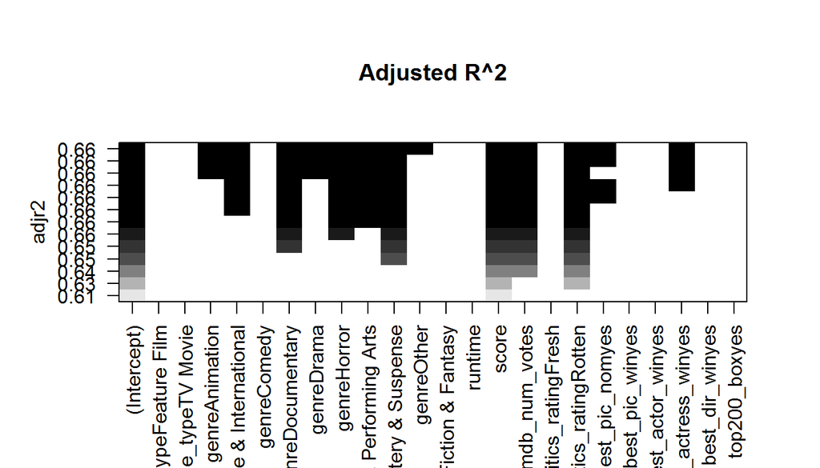

```r
plot(leaps,scale="adjr2",main="Adjusted R^2")
```

We then take the candidate model of specific number of variable with the highest adjusted R squared. This normally corresponds to the candidate model largest number of variables as it has more chance to improve the explained variability and also contains the rest of the variables.

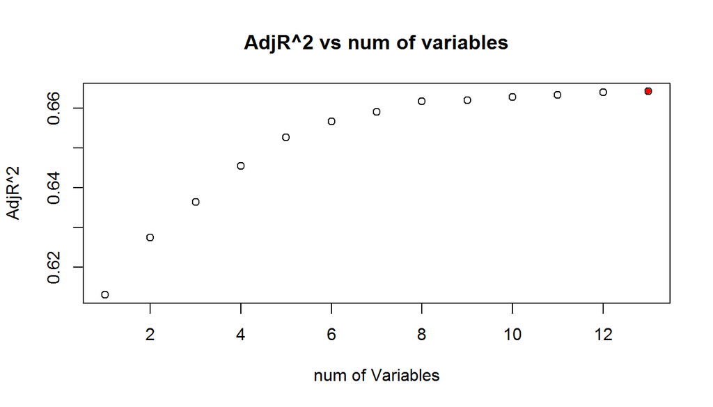

```r
leaps.summary<-summary(leaps)
plot(leaps.summary$adjr2, xlab = "num of Variables", ylab = "AdjR^2", main = "AdjR^2 vs num of variables")
idxAdjRSqrd<-which.max(leaps.summary$adjr2)
points(idxAdjRSqrd, leaps.summary$adjr2[idxAdjRSqrd], pch = 20, col = "red")
```

This maybe otherwise for other model selection criteria like the BIC (we minimize the BIC instead of maximizing it):

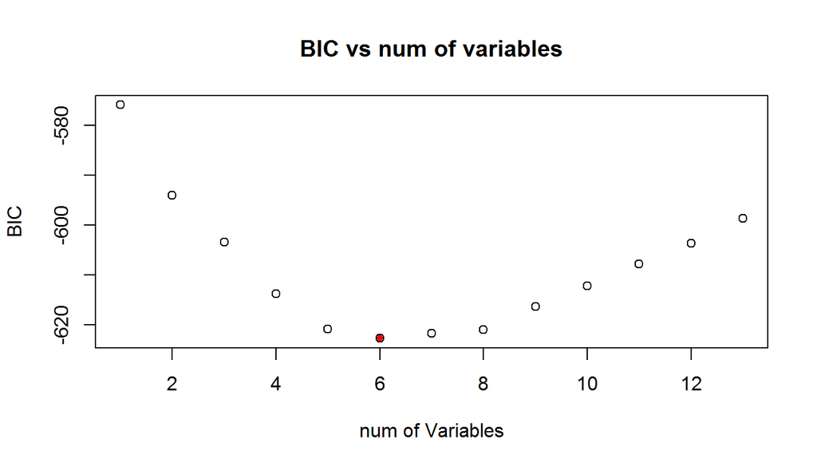

```r
plot(leaps.summary$bic, xlab = "num of Variables", ylab = "BIC", main = "BIC vs num of variables")
idxBICMin<-which.min(leaps.summary$bic)
points(idxBICMin, leaps.summary$bic[idxBICMin], pch = 20, col = "red")
```

Next, we determine the variables that are included in the model with the highest adjusted R squared, and then create the final model, **movies_mlr_final**.

```r
coef(leaps,idxAdjRSqrd)
```

```
##                    (Intercept)                 genreAnimation
##                    -19.4520640                      6.8262273
## genreArt House & International               genreDocumentary
##                     10.1155859                     11.3783592
##                     genreDrama                    genreHorror
##                      2.3532560                     -5.7952908
## genreMusical & Performing Arts        genreMystery & Suspense
##                     10.4633040                     -4.8226716
##                     genreOther                          score
##                      3.7888189                      0.9221914
##                limdb_num_votes           critics_ratingRotten
##                      4.6958013                      7.7134860
##                best_pic_nomyes            best_actress_winyes
##                      3.8937541                     -2.6138168
```

```r
movies_mlr_final<-lm(audience_score ~ genre + score + limdb_num_votes + critics_rating + best_pic_nom + best_actress_win, data=data_train)
movies_mlr_final
```

```
##
## Call:
## lm(formula = audience_score ~ genre + score + limdb_num_votes +
##     critics_rating + best_pic_nom + best_actress_win, data = data_train)
##
## Coefficients:
##                    (Intercept)                  genreAnimation
##                       -24.3673                          8.3290
## genreArt House & International                     genreComedy
##                        11.5991                          2.3589
##               genreDocumentary                      genreDrama
##                        12.9402                          3.6034
##                    genreHorror  genreMusical & Performing Arts
##                        -4.5222                         11.8658
##        genreMystery & Suspense                      genreOther
##                        -3.8111                          4.9346
## genreScience Fiction & Fantasy                           score
##                        -1.4178                          0.9332
##                limdb_num_votes             critics_ratingFresh
##                         5.1234                          1.6443
##           critics_ratingRotten                 best_pic_nomyes
##                         9.0982                          4.1336
##            best_actress_winyes
##                        -2.7052
```

**Model diagnostics**

Linearity:

Plot of residuals vs fitted values

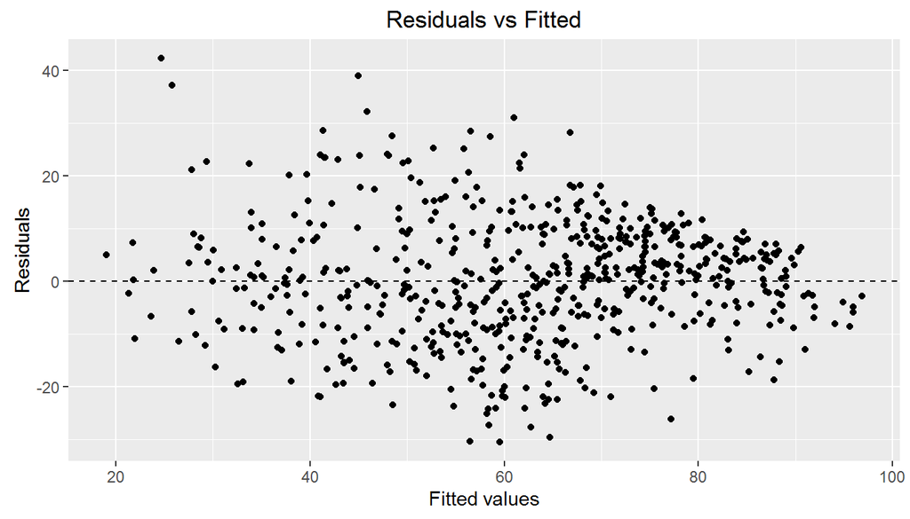

```r
ggplot(data = movies_mlr_final, aes(x = .fitted, y = .resid)) +
  geom_point() +
  geom_hline(yintercept = 0, linetype = "dashed") +
  xlab("Fitted values") +
  ylab("Residuals") +
  labs(title = "Residuals vs Fitted")
```

Random scatter around zero in residual plot. Hence relationship between response variable and explanatory variables should be linear.

Nearly normal residuals:

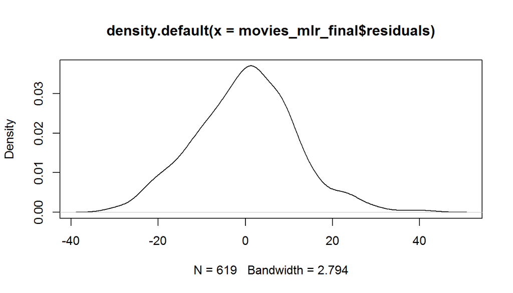

```r
plot(density(movies_mlr_final$residuals))
```

Normal probability plot of residuals

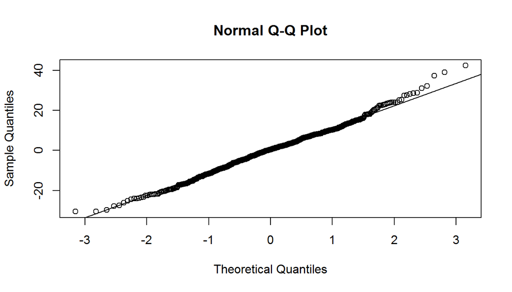

```r
qqnorm(movies_mlr_final$residuals)
qqline(movies_mlr_final$residuals)
```

From the histogram, residual distribution of the current model is slightly skewed to the right. And from the normal probability plot, there are some deviation from normality at the higher end. The condition for nearly normal residuals is only fairly satisfied.

Constant variability:

From the residuals vs fitted plot, the condition for constant variability is also only fairly satisfied.

**Interpretation of model coefficients**

```r
summary(movies_mlr_final)
```

```
##
## Call:
## lm(formula = audience_score ~ genre + score + limdb_num_votes +
##     critics_rating + best_pic_nom + best_actress_win, data = data_train)
##
## Residuals:
##     Min      1Q  Median      3Q     Max
## -30.539  -7.557   0.440   7.491  42.336
##
## Coefficients:
##                                 Estimate Std. Error t value Pr(>|t|)
## (Intercept)                    -24.36730    5.66587  -4.301 1.99e-05 ***
## genreAnimation                   8.32896    4.41819   1.885  0.05989 .
## genreArt House & International  11.59914    3.78955   3.061  0.00231 **
## genreComedy                      2.35893    1.98069   1.191  0.23414
## genreDocumentary                12.94016    2.83960   4.557 6.28e-06 ***
## genreDrama                       3.60340    1.74350   2.067  0.03918 *
## genreHorror                     -4.52223    2.92274  -1.547  0.12233
## genreMusical & Performing Arts  11.86583    3.84505   3.086  0.00212 **
## genreMystery & Suspense         -3.81109    2.20271  -1.730  0.08411 .
## genreOther                       4.93465    3.43798   1.435  0.15171
## genreScience Fiction & Fantasy  -1.41781    4.41507  -0.321  0.74822
## score                            0.93318    0.05257  17.753  < 2e-16 ***
## limdb_num_votes                  5.12340    0.82814   6.187 1.14e-09 ***
## critics_ratingFresh              1.64431    1.49519   1.100  0.27189
## critics_ratingRotten             9.09817    2.17004   4.193 3.17e-05 ***
## best_pic_nomyes                  4.13357    2.73976   1.509  0.13189
## best_actress_winyes             -2.70522    1.53716  -1.760  0.07893 .
## ---
## Signif. codes:  0 '***' 0.001 '**' 0.01 '*' 0.05 '.' 0.1 ' ' 1
##
## Residual standard error: 11.69 on 602 degrees of freedom
## Multiple R-squared:  0.6729, Adjusted R-squared:  0.6642
## F-statistic:  77.4 on 16 and 602 DF,  p-value: < 2.2e-16
```

Intercept:

Movies in the **Action & Adventure genre**, with **critics rating Certified Fresh**, **no Oscar best picture nomination**, **no Oscar best actress**, **zero log of IMDb number of votes**, and **zero score** are expected on average to have audience score of **-24.37**.

Slopes:

All else held constant, the model predicts that the Animation genre have **8.33** point **higher** in audience score than the Action & Adventure genre on average.

All else held constant, the model predicts that the Art House & International genre have **11.60** point **higher** in audience score than the Action & Adventure genre on average.

All else held constant, the model predicts that the Comedy genre have **2.36** point **higher** in audience score than the Action & Adventure genre on average.

All else held constant, the model predicts that the Documentary genre have **12.94** point **higher** in audience score than the Action & Adventure genre on average.

All else held constant, the model predicts that the Drama genre have **3.60** point **higher** in audience score than the Action & Adventure genre on average.

All else held constant, the model predicts that the Horror genre have **4.52** point **lower** in audience score than the Action & Adventure genre on average.

All else held constant, the model predicts that the Musical & Performing Arts genre have **11.87** point **higher** in audience score than the Action & Adventure genre on average.

All else held constant, the model predicts that the Mystery & Suspense genre have **3.81** point **lower** in audience score than the Action & Adventure genre on average.

All else held constant, the model predicts that the Other genre have **4.93** point **higher** in audience score than the Action & Adventure genre on average.

All else held constant, the model predicts that the Science Fiction & Fantasy genre have **1.42** point **lower** in audience score than the Action & Adventure genre on average.

All else held constant, for each 1 point increase in score the model predicts the audience score to be **higher** on average by **0.93** point.

All else held constant, for each 1 point increase in log of IMDb number of votes the model predicts the audience score to be **higher** on average by **5.12** point.

All else held constant, the model predicts that the critics rating Fresh have **1.64** point **higher** in audience score than the the critics rating Certified Fresh on average.

All else held constant, the model predicts that the critics rating Rotten have **9.10** point **higher** in audience score than the the critics rating Certified Fresh on average.

All else held constant, the model predicts that movies with Oscar best picture nomination have **4.13** point **higher** in audience score on average than the ones without Oscar Best Picture Nomination.

## Part 5: Prediction

Based on the multiple linear regression model we came up with, we would like to predict Rotten Tomatoes’ audience score for the movie “The Martian” of year 2015, which is not in the existing dataset. Below are the related details about the movie:

Movie: **The Martian**

Feature Film: **Yes**

Genre: **Science Fiction & Fantasy** [2]

Release date: **2 October 2015** [2]

Runtime: **164 min** [2]

MPAA Rating: **PG-13** [3]

IMDb Number of Votes: **470,917** [3]

IMDb Rating: **8.1** [3]

Rotten Tomatoes Critics Score: **92** [2]

Oscar Best Picture Nomination: **Yes** [4]

Oscar Best Picture Won: **No** [4]

Oscar Best Actor Award: **No** [5]

Oscar Best Actress Award: **No** [6]

Oscar Best Director Award: **No** [7]

Top200 Box Office Listing: **No** [8]

Making the prediction

```r
new_movie <- data.frame(genre = "Science Fiction & Fantasy", score = (8.1*10 + 92)/2, limdb_num_votes = log10(470917), critics_rating = "Certified Fresh", best_pic_nom = "yes", best_actress_win = "no")
predict(movies_mlr_final, new_movie)
```

```
##        1
## 88.13365
```

Prediction with 95% confidence interval

```r
predict(movies_mlr_final, new_movie, interval = "prediction", level = 0.95)
```

```
##        fit      lwr      upr
## 1 88.13365 63.21944 113.0479
```

## Part 6: Conclusion

From our model, we have learned that there are non-intuitive relationships between the variable **critics_rating** and **best_actress_win** against the response variable **audience_score**. It appears that having worst critics rating in Rotten Tomatoes site has positive effect on the audience score, and having Oscar Best Actress in the movie has negative effect on the audience score, according to our model.

One shortcoming of the current study is the limited quantity of explanatory variable for the linear regression and modeling. Apart from that, our current study also did not explore the interaction among the explanatory variables. In future studies, more explanatory variables should be included and also interaction among explanatory variables should be considered.

## References

[1] Codebook for Movies dataset. Retrieved 09 Aug, 2016 Link

[2] The Martian (2015) - Rotten Tomatoes. Retrieved 09 Aug, 2016. [Link](https://www.rottentomatoes.com/m/the_martian/)

[3] The Martian (2015) - IMDb. Retrieved 09 Aug, 2016. [Link](http://www.imdb.com/title/tt3659388/)

[4] The Martian - Awards - IMDb. Retrieve 09 Aug, 2016. [Link](http://www.imdb.com/title/tt3659388/awards)

[5] Matt Damon - Awards - IMDb. Retrieve 09 Aug, 2016. [Link](http://www.imdb.com/name/nm0000354/awards)

[6] Jessica Chastain - Awards - IMDb. Retrieve 09 Aug, 2016. [Link](http://www.imdb.com/name/nm1567113/awards)

[7] Ridley Scott - Awards - IMDb. Retrieve 09 Aug, 2016. [Link](http://www.imdb.com/name/nm0000631/awards)

[8] All Time Box Office Adjusted for Ticket Price Inflation. Retrieved 09 Aug, 2016. [Link](http://www.boxofficemojo.com/alltime/adjusted.htm)